# Regression and model validation

## Description of the dataset

My dataset for this exercise has 7 variables, gender is factor, age, attitude and points are integers and variables deep, stra and surf are double.

```
## 'data.frame':    166 obs. of  7 variables:
##  $ gender  : Factor w/ 2 levels "F","M": 1 2 1 2 2 1 2 1 2 1 ...
##  $ age     : int  53 55 49 53 49 38 50 37 37 42 ...
##  $ attitude: int  37 31 25 35 37 38 35 29 38 21 ...
##  $ points  : int  25 12 24 10 22 21 21 31 24 26 ...
##  $ deep    : num  3.58 2.92 3.5 3.5 3.67 ...
##  $ stra    : num  3.38 2.75 3.62 3.12 3.62 ...
##  $ surf    : num  2.58 3.17 2.25 2.25 2.83 ...
## NULL
```

First rows of the dataset look like this:

```
##   gender age attitude points     deep  stra     surf
## 1      F  53       37     25 3.583333 3.375 2.583333
## 2      M  55       31     12 2.916667 2.750 3.166667
## 3      F  49       25     24 3.500000 3.625 2.250000
## 4      M  53       35     10 3.500000 3.125 2.250000
## 5      M  49       37     22 3.666667 3.625 2.833333
## 6      F  38       38     21 4.750000 3.625 2.416667
```

Minimum and maximum values and some other descrptive numbers of the distribution:

```
##  gender       age           attitude         points           deep
##  F:110   Min.   :17.00   Min.   :14.00   Min.   : 7.00   Min.   :1.583
##  M: 56   1st Qu.:21.00   1st Qu.:26.00   1st Qu.:19.00   1st Qu.:3.333
##          Median :22.00   Median :32.00   Median :23.00   Median :3.667
##          Mean   :25.51   Mean   :31.43   Mean   :22.72   Mean   :3.680
##          3rd Qu.:27.00   3rd Qu.:37.00   3rd Qu.:27.75   3rd Qu.:4.083
##          Max.   :55.00   Max.   :50.00   Max.   :33.00   Max.   :4.917
##       stra            surf
##  Min.   :1.250   Min.   :1.583
##  1st Qu.:2.625   1st Qu.:2.417
##  Median :3.188   Median :2.833
##  Mean   :3.121   Mean   :2.787
##  3rd Qu.:3.625   3rd Qu.:3.167
##  Max.   :5.000   Max.   :4.333
```

## Variable selection

Below is a visual summary of the relationships in the data. Dependent variable for the linear model is going to be points.

Based on correlation and scatterplots variable Attitude seems a good candidate for an explanatory variable (correlation: 0.4).

As the two other variables for this regression I choose gender and age: it seems that the sign of regression terms might be different for men and women. This I want to investigate further.

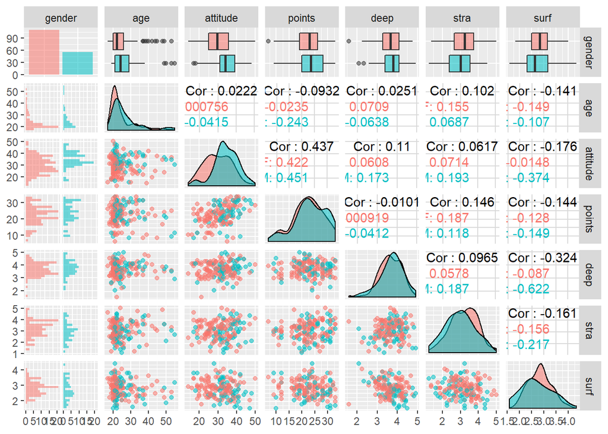

## Analysis

I also tried separate models for the two genders (not shown here) but age remained insignificant.

```
##
## Call:
## lm(formula = learning2014$points ~ learning2014$attitude + learning2014$age +
##     learning2014$gender)
##
## Residuals:
##      Min       1Q   Median       3Q      Max
## -17.4590  -3.3221   0.2186   4.0247  10.4632
##
## Coefficients:
##                       Estimate Std. Error t value Pr(>|t|)
## (Intercept)           13.42910    2.29043   5.863 2.48e-08 ***
## learning2014$attitude  0.36066    0.05932   6.080 8.34e-09 ***
## learning2014$age      -0.07586    0.05367  -1.414    0.159
## learning2014$genderM  -0.33054    0.91934  -0.360    0.720
## ---
## Signif. codes:  0 '***' 0.001 '**' 0.01 '*' 0.05 '.' 0.1 ' ' 1
##
## Residual standard error: 5.315 on 162 degrees of freedom
## Multiple R-squared:  0.2018, Adjusted R-squared:  0.187
## F-statistic: 13.65 on 3 and 162 DF,  p-value: 5.536e-08
```

Here is the linear model with the only statistically significant parameter attitude. Attitude is positively related to points variable. The final equation is:

points = 11.64 + attitude * 0.35

R-square statistic for this model is 0.1856, in other words attitude alone explains almost 20 % of the variation in points. This is quite a high pecentage! Below there’s a visualization of the model

```
##
## Call:
## lm(formula = learning2014$points ~ learning2014$attitude)
##
## Residuals:
##      Min       1Q   Median       3Q      Max
## -16.9763  -3.2119   0.4339   4.1534  10.6645
##
## Coefficients:
##                       Estimate Std. Error t value Pr(>|t|)
## (Intercept)           11.63715    1.83035   6.358 1.95e-09 ***
## learning2014$attitude  0.35255    0.05674   6.214 4.12e-09 ***
## ---
## Signif. codes:  0 '***' 0.001 '**' 0.01 '*' 0.05 '.' 0.1 ' ' 1
##
## Residual standard error: 5.32 on 164 degrees of freedom
## Multiple R-squared:  0.1906, Adjusted R-squared:  0.1856
## F-statistic: 38.61 on 1 and 164 DF,  p-value: 4.119e-09
```

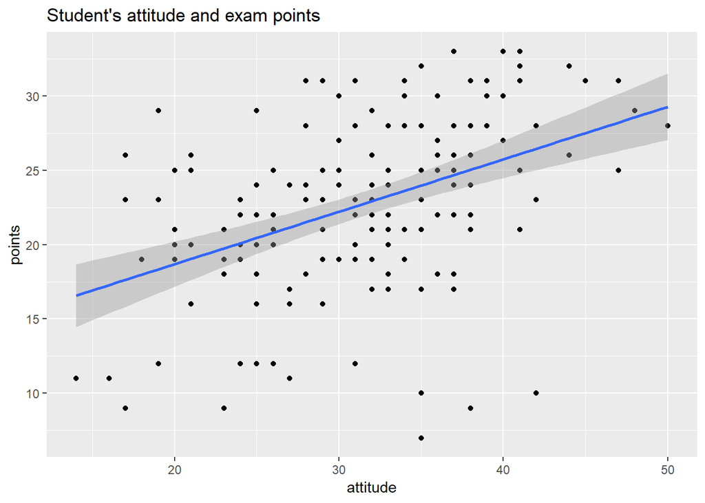

## Diagnostic of the model

In the normal model the basic equation is:

y = a + bx + error

Residuals vs. fitted values plot (below) shows that there exists no correlation or other kind of clear dependence between y values and error values.

Q-Q-plot shows that the standardized residuals approximately follow normal distribution. This means that the assumption of normality can be considered fulfilled.

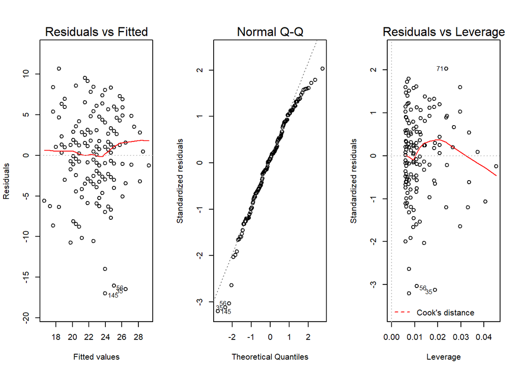

All in all, after examining the diagnostics’ plots it can be concluded that the model is valid.